# 6 Longtitudinal data

This week we work with two dataset, BPRS and RATS, and conduct the analyses in the MABS textbook chapter 8 and 9, but swapping the datasets..

## RATS

Dataset includes 16 rats, divided into 3 groups based on different diets.

```r
library(ggplot2)
library(tidyr)
library(dplyr)
ratsl <- read.csv(file = "~/IODS-project/data/ratsl.csv", row.names = 1)
# categorials into factors
ratsl$Group <- factor(ratsl$Group)
ratsl$ID <- factor(ratsl$ID)
# stardardize bprsl
ratsl <- ratsl %>% group_by(Time) %>% mutate(stweight = (Weight - mean(Weight)) / sd(Weight)) %>% ungroup()
str(ratsl)
```

```
## Classes 'tbl_df', 'tbl' and 'data.frame':    176 obs. of  6 variables:
##  $ ID      : Factor w/ 16 levels "1","2","3","4",..: 1 2 3 4 5 6 7 8 9 10 ...
##  $ Group   : Factor w/ 3 levels "1","2","3": 1 1 1 1 1 1 1 1 2 2 ...
##  $ WD      : Factor w/ 11 levels "WD1","WD15","WD22",..: 1 1 1 1 1 1 1 1 1 1 ...
##  $ Weight  : int  240 225 245 260 255 260 275 245 410 405 ...
##  $ Time    : int  1 1 1 1 1 1 1 1 1 1 ...
##  $ stweight: num  -1.001 -1.12 -0.961 -0.842 -0.882 ...
```

## Graphical exploration of longtitudinal data

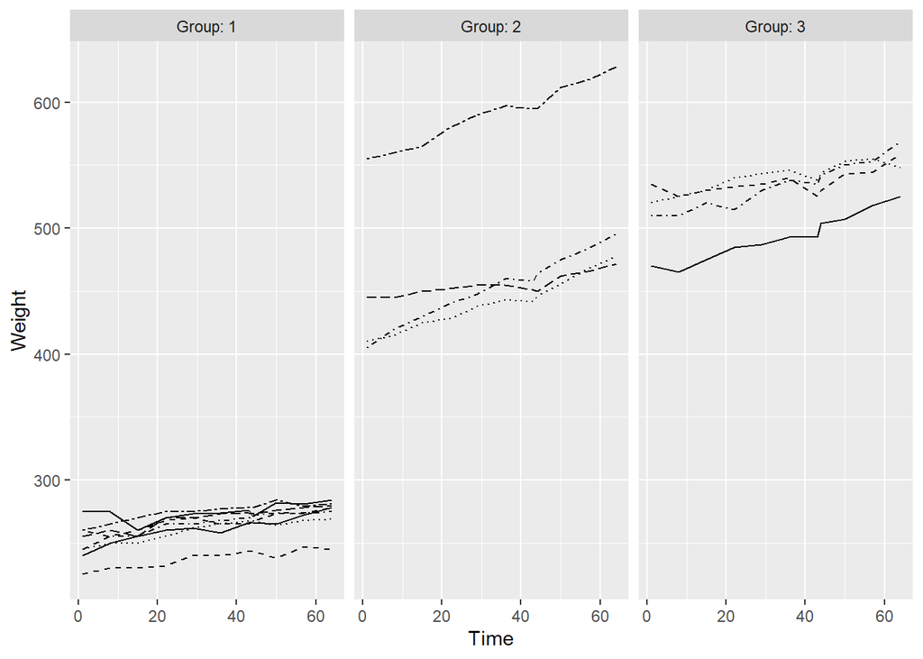

```r
# plot the individuals in time with standardized bprs value
ggplot(ratsl, aes(x = Time, y = Weight, linetype = ID)) + geom_line() + facet_grid(. ~ Group, labeller = label_both) + scale_linetype_manual(values = rep(1:6, times=4)) + theme(legend.position = "none") +   scale_y_continuous(limits = c(min(ratsl$Weight), max(ratsl$Weight)))
```

```r
# Summary plot
# Number of timepoints, baseline included
n <- ratsl$Time %>% unique() %>% length()
# Summarize mean and std error
ratssum <- ratsl %>% group_by(Group, Time) %>% summarise(mean = mean(Weight), se = ( sd(Weight) / sqrt(n) )) %>% ungroup()
glimpse(ratssum)
```

```
## Observations: 33
## Variables: 4
## $ Group <fct> 1, 1, 1, 1, 1, 1, 1, 1, 1, 1, 1, 2, 2, 2, 2, 2, 2, 2, 2,...
## $ Time  <int> 1, 8, 15, 22, 29, 36, 43, 44, 50, 57, 64, 1, 8, 15, 22, ...
## $ mean  <dbl> 250.625, 255.000, 254.375, 261.875, 264.625, 265.000, 26...
## $ se    <dbl> 4.589478, 3.947710, 3.460116, 4.100800, 3.333956, 3.5529...
```

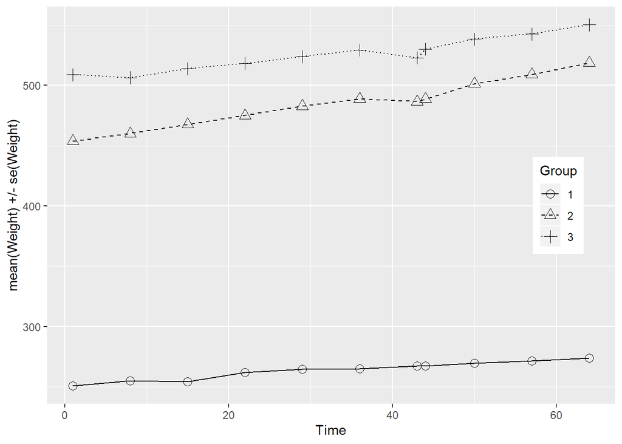

```r
# plot the plots
par(mfrow = c(1,2))
# with means only
ggplot(ratssum, aes(x = Time, y = mean, linetype = Group, shape = Group)) +
  geom_line() +
  scale_linetype_manual(values = c(1,2,3)) +
  geom_point(size=3) +
  scale_shape_manual(values = c(1,2,3)) +
  theme(legend.position = c(0.9,0.5)) +
  scale_y_continuous(name = "mean(Weight) +/- se(Weight)")
```

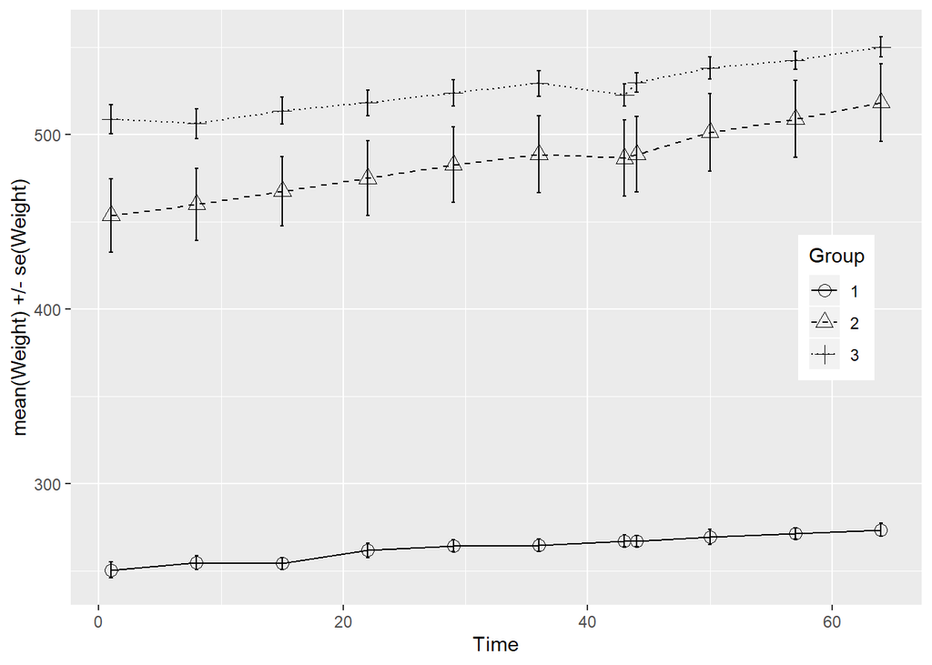

```r
# added with the error bar
ggplot(ratssum, aes(x = Time, y = mean, linetype = Group, shape = Group)) +
  geom_line() +
  scale_linetype_manual(values = c(1,2,3)) +
  geom_point(size=3) +
  scale_shape_manual(values = c(1,2,3)) +
  geom_errorbar(aes(ymin=mean-se, ymax=mean+se, linetype="1"), width=0.3) +
  theme(legend.position = c(0.9,0.5)) +
  scale_y_continuous(name = "mean(Weight) +/- se(Weight)")
```

Group means increase in time. Second plot includes the standard error bars.

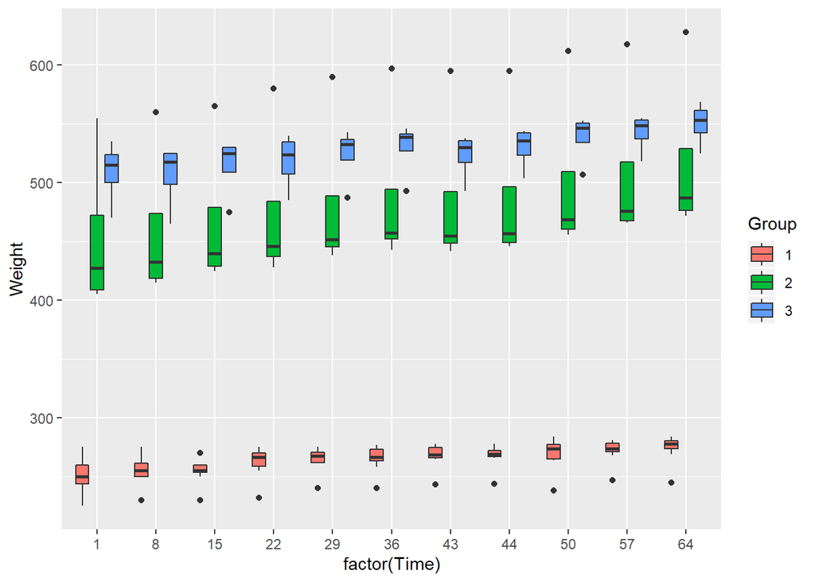

```r
# boxplot
ggplot(ratsl, aes(x = factor(Time), y = Weight, fill = Group)) + geom_boxplot()
```

Boxplots with non-summarized data.

## Preparinf the summary measure approach

```r
# Summary measure approach, filter out outliers
# create the summary dataset with means from the weeks 1-8
rat8s <- ratsl %>%
  filter(Time > 0) %>%
  group_by(Group, ID) %>%
  summarise( mean=mean(Weight) ) %>%
  ungroup()
glimpse(rat8s)
```

```
## Observations: 16
## Variables: 3
## $ Group <fct> 1, 1, 1, 1, 1, 1, 1, 1, 2, 2, 2, 2, 3, 3, 3, 3
## $ ID    <fct> 1, 2, 3, 4, 5, 6, 7, 8, 9, 10, 11, 12, 13, 14, 15, 16
## $ mean  <dbl> 261.0909, 237.6364, 260.1818, 266.5455, 269.4545, 274.72...
```

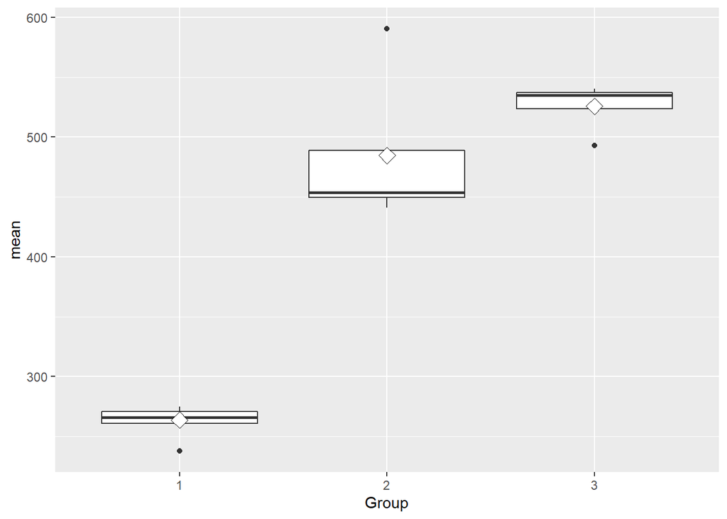

```r
ggplot(rat8s, aes(x=Group, y = mean)) + geom_boxplot() + stat_summary(fun.y = "mean", geom = "point", shape=23, size=4, fill = "white")
```

```r
# filter the outlier(s) and plot again
glimpse(rat8s)
```

```
## Observations: 16
## Variables: 3
## $ Group <fct> 1, 1, 1, 1, 1, 1, 1, 1, 2, 2, 2, 2, 3, 3, 3, 3
## $ ID    <fct> 1, 2, 3, 4, 5, 6, 7, 8, 9, 10, 11, 12, 13, 14, 15, 16
## $ mean  <dbl> 261.0909, 237.6364, 260.1818, 266.5455, 269.4545, 274.72...
```

```r
rat8s1 <- filter(rat8s, Group == 2 & mean < 550 | Group == 1 & mean > 260 | Group == 3 & mean > 500)
glimpse(rat8s1)
```

```
## Observations: 13
## Variables: 3
## $ Group <fct> 1, 1, 1, 1, 1, 1, 1, 2, 2, 2, 3, 3, 3
## $ ID    <fct> 1, 3, 4, 5, 6, 7, 8, 9, 10, 11, 14, 15, 16
## $ mean  <dbl> 261.0909, 260.1818, 266.5455, 269.4545, 274.7273, 274.63...
```

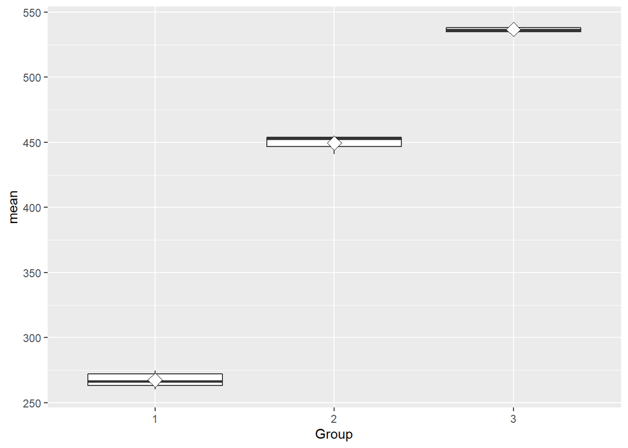

```r
ggplot(rat8s1, aes(x=Group, y = mean)) + geom_boxplot() + stat_summary(fun.y = "mean", geom = "point", shape=23, size=4, fill = "white")
```

Three outliers dropped, one from each group.

## Summary approach, comparing means

```r
summary(aov(mean ~ Group, data = rat8s1))
```

```
##             Df Sum Sq Mean Sq F value   Pr(>F)
## Group        2 175958   87979    2577 2.72e-14 ***
## Residuals   10    341      34
## ---
## Signif. codes:  0 '***' 0.001 '**' 0.01 '*' 0.05 '.' 0.1 ' ' 1
```

```r
kruskal.test(mean ~ Group, data = rat8s1)
```

```
##
##  Kruskal-Wallis rank sum test
##
## data:  mean by Group
## Kruskal-Wallis chi-squared = 9.8901, df = 2, p-value = 0.007119
```

Differences between group means are statistically significant according to both tests.

```r
# covariance analysis with the baseline
# add the baseline from the original wide dataset to the summary data
rats <- read.csv(file = "~/IODS-project/data/rats.csv", row.names = 1)
rat8s2 <- rat8s %>% mutate(baseline = rats$WD1)
glimpse(rat8s2)
```

```
## Observations: 16
## Variables: 4
## $ Group    <fct> 1, 1, 1, 1, 1, 1, 1, 1, 2, 2, 2, 2, 3, 3, 3, 3
## $ ID       <fct> 1, 2, 3, 4, 5, 6, 7, 8, 9, 10, 11, 12, 13, 14, 15, 16
## $ mean     <dbl> 261.0909, 237.6364, 260.1818, 266.5455, 269.4545, 274...
## $ baseline <int> 240, 225, 245, 260, 255, 260, 275, 245, 410, 405, 445...
```

```r
# ANCOVA
fit <- lm(mean ~ baseline + Group, data = rat8s2)
summary(fit)
```

```
##
## Call:
## lm(formula = mean ~ baseline + Group, data = rat8s2)
##
## Residuals:
##     Min      1Q  Median      3Q     Max
## -21.732  -3.812   1.991   6.889  13.455
##
## Coefficients:
##             Estimate Std. Error t value Pr(>|t|)
## (Intercept) 30.14886   19.88779   1.516   0.1554
## baseline     0.93194    0.07793  11.959 5.02e-08 ***
## Group2      31.68866   17.11189   1.852   0.0888 .
## Group3      21.52296   21.13931   1.018   0.3287
## ---
## Signif. codes:  0 '***' 0.001 '**' 0.01 '*' 0.05 '.' 0.1 ' ' 1
##
## Residual standard error: 10.62 on 12 degrees of freedom
## Multiple R-squared:  0.9947, Adjusted R-squared:  0.9933
## F-statistic: 747.8 on 3 and 12 DF,  p-value: 6.636e-14
```

The covariance analysis reveals, that the baseline is highly related to the means in later time. And, after controlling the baseline, there is no significant diffence left between the group means.

## BPRS

Do the growth profiles of the treatment groups differ?

```r
# read the data, in long form
bprsl <- read.csv(file = "~/IODS-project/data/bprsl.csv", row.names = 1)
bprsl$treatment <- factor(bprsl$treatment)
bprsl$subject <- factor(bprsl$subject)
glimpse(bprsl)
```

```
## Observations: 360
## Variables: 4
## $ treatment <fct> 1, 1, 1, 1, 1, 1, 1, 1, 1, 1, 1, 1, 1, 1, 1, 1, 1, 1...
## $ subject   <fct> 1, 2, 3, 4, 5, 6, 7, 8, 9, 10, 11, 12, 13, 14, 15, 1...
## $ weeks     <int> 0, 0, 0, 0, 0, 0, 0, 0, 0, 0, 0, 0, 0, 0, 0, 0, 0, 0...
## $ bprs      <int> 42, 58, 54, 55, 72, 48, 71, 30, 41, 57, 30, 55, 36, ...
```

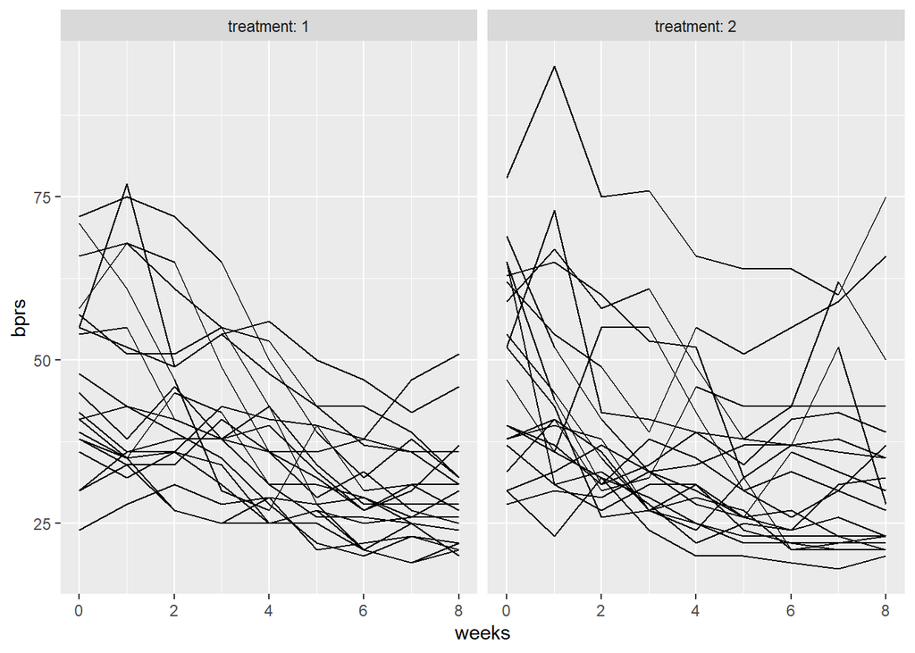

```r
ggplot(bprsl, aes(x = weeks, y = bprs, group = subject)) + geom_line() + facet_grid(. ~ treatment, labeller = label_both)
```

```r
bps_reg <- lm(bprs ~ weeks + treatment, data=bprsl)
summary(bps_reg)
```

```
##
## Call:
## lm(formula = bprs ~ weeks + treatment, data = bprsl)
##
## Residuals:
##     Min      1Q  Median      3Q     Max
## -22.454  -8.965  -3.196   7.002  50.244
##
## Coefficients:
##             Estimate Std. Error t value Pr(>|t|)
## (Intercept)  46.4539     1.3670  33.982   <2e-16 ***
## weeks        -2.2704     0.2524  -8.995   <2e-16 ***
## treatment2    0.5722     1.3034   0.439    0.661
## ---
## Signif. codes:  0 '***' 0.001 '**' 0.01 '*' 0.05 '.' 0.1 ' ' 1
##
## Residual standard error: 12.37 on 357 degrees of freedom
## Multiple R-squared:  0.1851, Adjusted R-squared:  0.1806
## F-statistic: 40.55 on 2 and 357 DF,  p-value: < 2.2e-16
```

Linear regression model with bprs as response and weeks and treatment group as explanatory variables. From coefficient we see, that bprs decreases in time, but treatment group is not significant.

### Random intercept model

```r
library(lme4)
bps_ref <- lmer(bprs ~ weeks + treatment + (1|subject), data = bprsl, REML=FALSE)
summary(bps_ref)
```

```
## Linear mixed model fit by maximum likelihood  ['lmerMod']
## Formula: bprs ~ weeks + treatment + (1 | subject)
##    Data: bprsl
##
##      AIC      BIC   logLik deviance df.resid
##   2748.7   2768.1  -1369.4   2738.7      355
##
## Scaled residuals:
##     Min      1Q  Median      3Q     Max
## -3.0481 -0.6749 -0.1361  0.4813  3.4855
##
## Random effects:
##  Groups   Name        Variance Std.Dev.
##  subject  (Intercept)  47.41    6.885
##  Residual             104.21   10.208
## Number of obs: 360, groups:  subject, 20
##
## Fixed effects:
##             Estimate Std. Error t value
## (Intercept)  46.4539     1.9090  24.334
## weeks        -2.2704     0.2084 -10.896
## treatment2    0.5722     1.0761   0.532
##
## Correlation of Fixed Effects:
##            (Intr) weeks
## weeks      -0.437
## treatment2 -0.282  0.000
```

### Random intercept and random slope model

```r
bps_ref2 <- lmer(bprs ~ weeks + treatment + (weeks|subject), data = bprsl, REML=FALSE)
summary(bps_ref2)
```

```
## Linear mixed model fit by maximum likelihood  ['lmerMod']
## Formula: bprs ~ weeks + treatment + (weeks | subject)
##    Data: bprsl
##
##      AIC      BIC   logLik deviance df.resid
##   2745.4   2772.6  -1365.7   2731.4      353
##
## Scaled residuals:
##     Min      1Q  Median      3Q     Max
## -2.8919 -0.6194 -0.0691  0.5531  3.7977
##
## Random effects:
##  Groups   Name        Variance Std.Dev. Corr
##  subject  (Intercept) 64.8222  8.0512
##           weeks        0.9609  0.9803   -0.51
##  Residual             97.4304  9.8707
## Number of obs: 360, groups:  subject, 20
##
## Fixed effects:
##             Estimate Std. Error t value
## (Intercept)  46.4539     2.1052  22.066
## weeks        -2.2704     0.2977  -7.626
## treatment2    0.5722     1.0405   0.550
##
## Correlation of Fixed Effects:
##            (Intr) weeks
## weeks      -0.582
## treatment2 -0.247  0.000
```

```r
anova(bps_ref, bps_ref2)
```

```
## Data: bprsl
## Models:
## bps_ref: bprs ~ weeks + treatment + (1 | subject)
## bps_ref2: bprs ~ weeks + treatment + (weeks | subject)
##          Df    AIC    BIC  logLik deviance  Chisq Chi Df Pr(>Chisq)
## bps_ref   5 2748.7 2768.1 -1369.4   2738.7
## bps_ref2  7 2745.4 2772.6 -1365.7   2731.4 7.2721      2    0.02636 *
## ---
## Signif. codes:  0 '***' 0.001 '**' 0.01 '*' 0.05 '.' 0.1 ' ' 1
```

The model fit is better in model 2.

### Random intercept and random slope model with interaction

```r
bps_ref3 <- lmer(bprs ~ weeks * treatment + (weeks|subject), data = bprsl, REML=FALSE)
summary(bps_ref3)
```

```
## Linear mixed model fit by maximum likelihood  ['lmerMod']
## Formula: bprs ~ weeks * treatment + (weeks | subject)
##    Data: bprsl
##
##      AIC      BIC   logLik deviance df.resid
##   2744.3   2775.4  -1364.1   2728.3      352
##
## Scaled residuals:
##     Min      1Q  Median      3Q     Max
## -3.0512 -0.6271 -0.0768  0.5288  3.9260
##
## Random effects:
##  Groups   Name        Variance Std.Dev. Corr
##  subject  (Intercept) 64.9964  8.0620
##           weeks        0.9687  0.9842   -0.51
##  Residual             96.4707  9.8220
## Number of obs: 360, groups:  subject, 20
##
## Fixed effects:
##                  Estimate Std. Error t value
## (Intercept)       47.8856     2.2521  21.262
## weeks             -2.6283     0.3589  -7.323
## treatment2        -2.2911     1.9090  -1.200
## weeks:treatment2   0.7158     0.4010   1.785
##
## Correlation of Fixed Effects:
##             (Intr) weeks  trtmn2
## weeks       -0.650
## treatment2  -0.424  0.469
## wks:trtmnt2  0.356 -0.559 -0.840
```

```r
anova(bps_ref2, bps_ref3)
```

```
## Data: bprsl
## Models:
## bps_ref2: bprs ~ weeks + treatment + (weeks | subject)
## bps_ref3: bprs ~ weeks * treatment + (weeks | subject)
##          Df    AIC    BIC  logLik deviance  Chisq Chi Df Pr(>Chisq)
## bps_ref2  7 2745.4 2772.6 -1365.7   2731.4
## bps_ref3  8 2744.3 2775.4 -1364.1   2728.3 3.1712      1    0.07495 .
## ---
## Signif. codes:  0 '***' 0.001 '**' 0.01 '*' 0.05 '.' 0.1 ' ' 1
```

The fit is not significantly better in model 3.

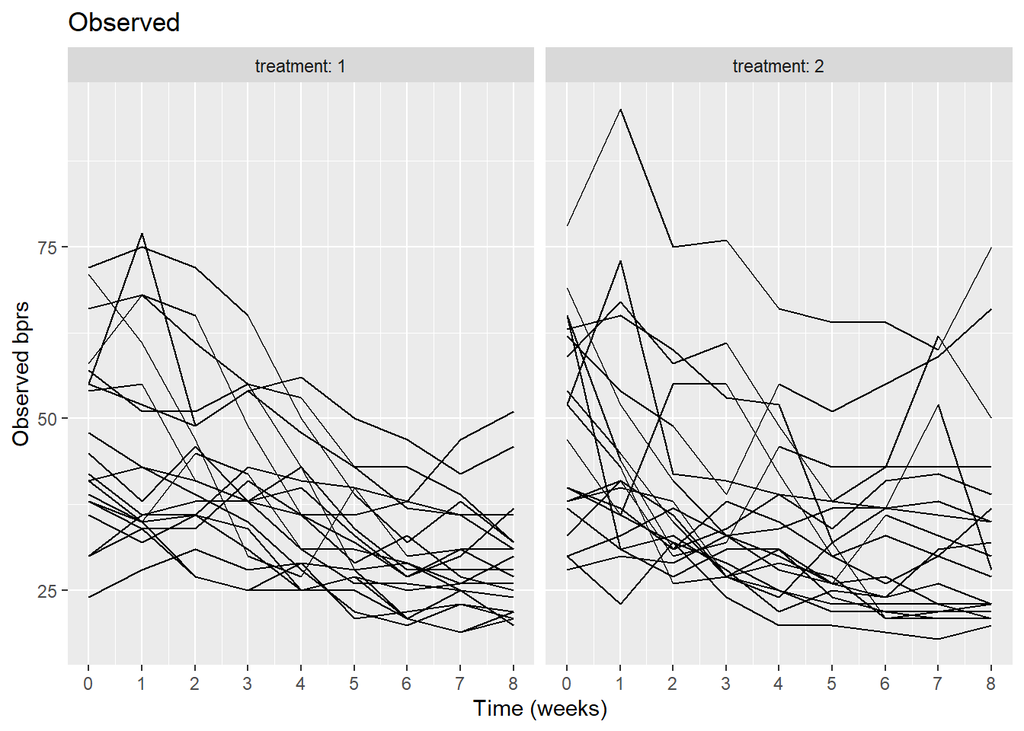

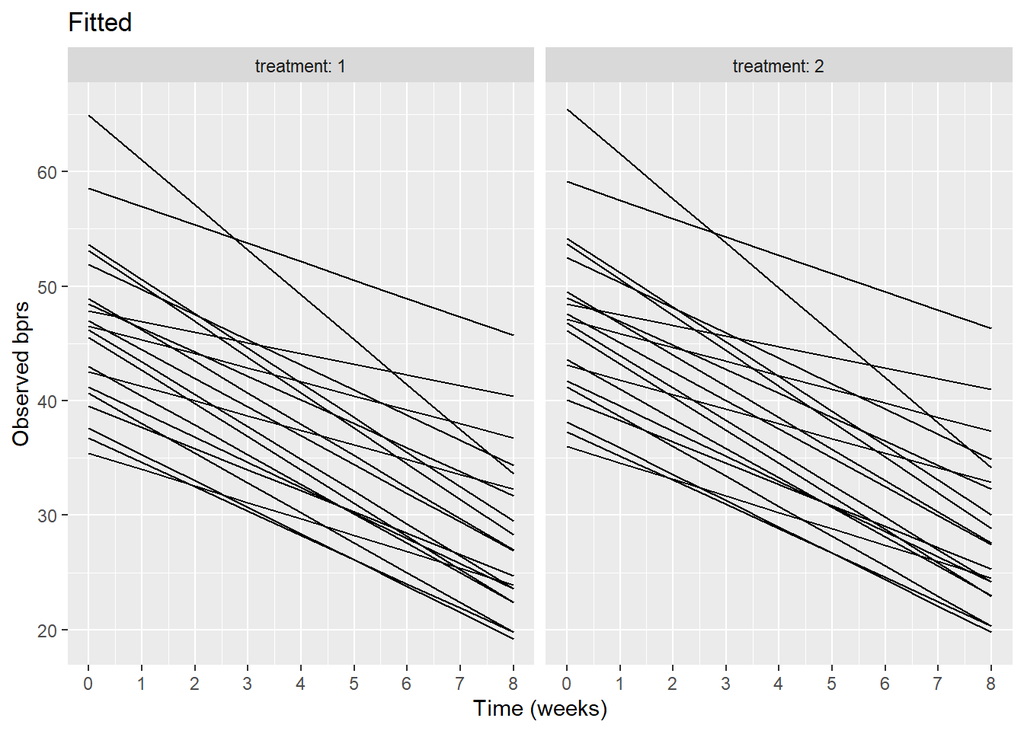

```r
# Create a vector of the fitted values
Fitted <- fitted(bps_ref2)
bprsl <- bprsl %>% mutate(Fitted)

# draw the plot of BPRSL with the observed bprs values
p1 <- ggplot(bprsl, aes(x = weeks, y = bprs, group = subject)) + geom_line() + facet_grid(. ~ treatment, labeller = label_both) + scale_x_continuous(name = "Time (weeks)", breaks = seq(0, 8, 1)) +  scale_y_continuous(name = "Observed bprs") + theme(legend.position = "top") + ggtitle("Observed")

# draw the plot with fitted
p2 <- ggplot(bprsl, aes(x = weeks, y = Fitted, group = subject)) +
  geom_line() + facet_grid(. ~ treatment, labeller = label_both) +
  scale_x_continuous(name = "Time (weeks)", breaks = seq(0, 8, 1)) +
  scale_y_continuous(name = "Observed bprs") +
  theme(legend.position = "top") + ggtitle("Fitted")

p1; p2
```